# Search: Solving a Maze Using a Goal-based Agent

Student Name: Logan Choi

## Instructions

Total Points: Undergrads 100 + 5 bonus / Graduate students 110

Complete this notebook. Use the provided notebook cells and insert additional code and markdown cells as needed. Submit the notebook file and the completely rendered notebook with all outputs as a HTML file.

## Introduction

The agent must use a map it is given to plan a path through the maze from the starting location $S$ to the goal location $G$. This is a planing exercise for a goal-based agent, so you do not need to implement an environment, just use the map to search for a path. Once the plan is made, the agent in a deterministic environment (i.e., the transition function is deterministic with the outcome of each state/action pair fixed and no randomness) can just follow the path and does not need to care about the percepts. This is also called an **[open-loop system](https://en.wikipedia.org/wiki/Open-loop_controller).** The execution phase is trivial and can be executed using a model-based reflex agent that ignores all percepts and just follows the plan. We do not implement it in this exercise.

Given that the agent has a complete and correct map, the environment is **fully observable, discrete, deterministic, and known.** Remember:

- **Fully observable** means that the agent can see its state and what the available actions are. That means the **percepts contain the complete current state.** Here, during planning, the agent always sees its x and y coordinates on the map and also seeks when it has reached the goal state.
- **Discrete** means that we have a **finite set of states.** The maze has a finite set of squares the agent can be in.
- **Deterministic** means that the **transition function contains no randomness.** An action in a state will always produce the same result. Going south from the start state always will lead to the same square.
- **Know** means that the agent **knows the complete transition function.** The agent has the map and therefore knows how its position changes when it walks in a direction.

Tree search algorithm implementations that you find online typically come from data structures courses and have a different aim than AI tree search. These algorithms assume that you already have a tree in memory. We are interested in dynamically creating a search tree with the aim of finding a good/the best path from the root note to the goal state. Follow the pseudo code presented in the text book (and replicated in the slides) closely. Ideally, we would like to search only a small part of the maze, i.e., create a search tree with as few nodes as possible.

Several mazes for this exercise are stored as text files. Here is the small example maze:

```python
with open("small_maze.txt", "r") as f:
    maze_str = f.read()
print(maze_str)
```

```
XXXXXXXXXXXXXXXXXXXXXX
X XX        X X      X
X    XXXXXX X XXXXXX X
XXXXXX     S  X      X
X    X XXXXXX XX XXXXX
X XXXX X         X   X
X        XXX XXX   X X
XXXXXXXXXX    XXXXXX X
XG         XX        X
XXXXXXXXXXXXXXXXXXXXXX
```

**Note:** If you get an error here that the file cannot be found, then you need to download it. See [HOWTO Work on Assignments.](https://github.com/mhahsler/CS7320-AI/blob/master/HOWTOs/working_on_assignments.md)

## Parsing and pretty printing the maze

The maze can also be displayed in color using code in the module maze_helper.py. The code parses the string representing the maze and converts it into a `numpy` 2d array which you can use in your implementation. Position are represented as a 2-tuple of the form `(row, col)`.

```python
import maze_helper as mh

maze = mh.parse_maze(maze_str)

# look at a position in the maze by subsetting the 2d array
print("Position(0,0):", maze[0, 0])

# there is also a helper function called `look(maze, pos)` available
# which uses a 2-tuple for the position.
print("Position(8,1):", mh.look(maze, (8, 1)))
```

```
Position(0,0): X
Position(8,1): G
```

A helper function to visualize the maze is also available.

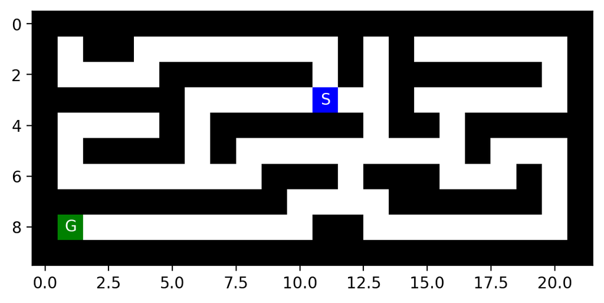

```python
%matplotlib inline
%config InlineBackend.figure_format = 'retina'
# use higher resolution images in notebooks

mh.show_maze(maze)
```

Find the `(x,y)` position of the start and the goal using the helper function `find_pos()`

```python
print("Start location:", mh.find_pos(maze, what = "S"))
print("Goal location:", mh.find_pos(maze, what = "G"))
```

```
Start location: (np.int64(3), np.int64(11))
Goal location: (np.int64(8), np.int64(1))
```

Helper function documentation.

```python
help(mh)
```

```
Help on module maze_helper:

NAME
    maze_helper

DESCRIPTION
    Code for the Maze Assignment by Michael Hahsler
    Usage:
        import maze_helper as mh
        mh.show_some_mazes()

FUNCTIONS
    animate_maze(result, repeat=False)
        Build an animation from a list of mazes. Assumes that results has the elements:
        path, reached, actions and maze_anim with a list of maze arrays.

    find_pos(maze, what='S')
        Find start/goal in a maze and returns the first one.
        Caution: there is no error checking!

        Parameters:
        maze: a array with characters prodced by parse_maze()
        what: the letter to be found ('S' for start and 'G' for goal)

        Returns:
        a tupple (x, y) for the found position.

    look(maze, pos)
        Look at the label of a square with the position as an array of the form (x, y).

    maze_to_matrix(maze)
        convert a maze a numeric numpy array for visualization via imshow.

    parse_maze(maze_str)
        Convert a maze as a string into a 2d numpy array

    show_maze(maze, fontsize=10)
        Display a (parsed) maze as an image.

    welcome()
        Welcome message.

DATA
    __warningregistry__ = {'version': 631}

FILE
    /Users/loganchoi/Desktop/maze/maze_helper.py
```

You will need to make a local copy of the module file maze_helper.py in the same folder where your notebook is.

## Tree structure

Here is an implementation of the basic node structure for the search algorithms (see Fig 3.7 on page 73). I have added a method that extracts the path from the root node to the current node. It can be used to get the path when the search is completed.

```python
class Node:
    def __init__(self, pos, parent, action, cost):
        self.pos = tuple(pos)    # the state; positions are (row, col)
        self.parent = parent     # reference to parent node. None means root node.
        self.action = action     # action used in the transition function (root node has None)
        self.cost = cost         # for uniform cost this is the depth. It is also g(n) for A* search

    def __lt__(self, other):
        # Compare nodes based on the Manhattan distance (used for greedy best-first search and A*).
        return self.cost < other.cost

    def __str__(self):
        return f"Node - pos = {self.pos}; action = {self.action}; cost = {self.cost}"

    def get_path_from_root(self):
        """returns nodes on the path from the root to the current node."""
        node = self
        path = [node]

        while not node.parent is None:
            node = node.parent
            path.append(node)

        path.reverse()

        return path
```

If needed, then you can add more fields to the class like the heuristic value $h(n)$ or $f(n)$.

# Tasks

The goal is to:

1. Implement the following search algorithms for solving different mazes:
   - Breadth-first search (BFS)
   - Depth-first search (DFS)
   - Greedy best-first search (GBFS)
   - A* search
2. Run each of the above algorithms on the
   - small maze,
   - medium maze,
   - large maze,
   - open maze,
   - wall maze,
   - loops maze,
   - empty maze, and
   - empty 2_maze.
3. For each problem instance and each search algorithm, report the following in a table:
   - The solution and its path cost
   - Total number of nodes expanded
   - Maximum tree depth
   - Maximum size of the frontier
4. Display each solution by marking every maze square (or state) visited and the squares on the final path.

## General [10 Points]

1. Make sure that you use the latest version of this notebook.
2. Your implementation can use libraries like math, numpy, scipy, but not libraries that implement intelligent agents or complete search algorithms. Try to keep the code simple! In this course, we want to learn about the algorithms and we often do not need to use object-oriented design.
3. You notebook needs to be formatted professionally.
   - Add additional markdown blocks for your description, comments in the code, add tables and use mathplotlib to produce charts where appropriate
   - Do not show debugging output or include an excessive amount of output.
   - Check that your submitted file is readable and contains all figures.
4. Document your code. Use comments in the code and add a discussion of how your implementation works and your design choices.

## Task 1: Defining the search problem and determining the problem size [10 Points]

Define the components of the search problem:

- Initial state
- Actions
- Transition model
- Goal state
- Path cost

Use verbal descriptions, variables and equations as appropriate.

1. Initial state: The initial state of the search problem is the initial position of the agent within the maze. Denoted by S -> (r, c) where r and c represent the row and column within the 2D maze.
2. Actions:
- Up (r, c) -> (r - 1, c)
- Down (r, c) -> (r + 1, c)
- Left (r, c) -> (r, c - 1)
- Right (r, c) -> (r, c + 1)
3. Transition model: Move from one coordinate to another.
4. Goal state: The specified coordinate within the given maze denoted by G.
5. Path cost: The total number of moves taken to reach the goal.

Give some estimates for the problem size:

- $n$: state space size
- $d$: depth of the optimal solution
- $m$: maximum depth of tree
- $b$: maximum branching factor

Describe how you would determin these values for a given maze.

1. $n$: state space size: The total number of valid positions (states) in the maze. $n$ = total number of open cells = m × n − walls
2. $d$: depth of the optimal solution: The length of the shortest path from the start state S to the goal state G.
3. $m$: maximum depth of tree: The longest possible path in the worst-case scenario. If loops or dead ends exist, DFS may go deeper before backtracking.
4. $b$: maximum branching factor: The maximum number of successors a state can have. In a grid-based maze with four possible movement directions (up, down, left, right), the branching factor is at most 4, but walls and boundaries reduce it.

## Task 2: Uninformed search: Breadth-first and depth-first [40 Points]

Implement these search strategies. Follow the pseudocode in the textbook/slides. You can use the tree structure shown above to extract the final path from your solution.

Read the following **important notes** carefully:

- You can find maze solving implementations online that use the map to store information. While this is an effective idea for this two-dimensional navigation problem, it typically cannot be used for other search problems. Therefore, follow the textbook and **do not store information in the map.** Only store information in the tree created during search, and use the `reached` and `frontier` data structures where appropriate.
- DSF behavior can be implemented using the BFS tree search algorithm and simply changing the order in which the frontier is expanded (this is equivalent to best-first search with path length as the criterion to expand the next node). However, this would be a big mistake since it combines the bad space complexity of BFS with the bad time complexity of DFS! **To take advantage of the significantly smaller memory footprint of DFS, you need to implement DFS in a different way without a `reached` data structure (often also called `visited` or `explored`) and by releasing the memory for nodes that are not needed anymore.**
- Since the proper implementation of DFS does not use a `reached` data structure, redundant path checking abilities are limited to cycle checking. You need to implement **cycle checking since DSF is incomplete (produces an infinite loop) if cycles cannot be prevented.** You will see in your experiments that cycle checking in open spaces is challenging.

```python
# Frontier
from collections import deque
```

```python
# Actions
ACTIONS = {
    "UP": (-1, 0),
    "DOWN": (1, 0),
    "LEFT": (0, -1),
    "RIGHT": (0, 1)
}
```

```python
def is_valid(maze, pos):
    """
    Check if a position is valid in the maze.
    Valid means it is within bounds and is not a wall ('X').
    """
    row, col = pos
    if row < 0 or col < 0 or row >= len(maze) or col >= len(maze[0]):
        return False  # Out of bounds
    return maze[row][col] != 'X'  # Wall check: 'X' is a wall
```

```python
# Expand
def expand(node, maze, reached):
    """Generates valid child nodes from the current node."""
    children = []
    row, col = node.pos

    for action, (dr, dc) in ACTIONS.items():
        new_pos = (row + dr, col + dc)

        # Check if the new position is valid and not visited
        if is_valid(maze, new_pos) and new_pos not in reached:
            new_node = Node(new_pos, node, action, node.cost + 1)
            children.append(new_node)
            reached.add(new_pos)  # Mark as visited

    return children
```

```python
# Breadth-first search
def bfs(maze):
    start_pos = mh.find_pos(maze, what="S")
    start_node = Node(start_pos, None, None, 0)  # Start node with cost 0

    frontier = deque([start_node])  # Queue for BFS
    reached = set([start_node.pos])  # Track visited positions

    # Statistics tracking
    nodes_expanded = 0
    max_tree_depth = 0
    max_nodes_in_memory = 1
    max_frontier_size = 1

    while frontier:
        current_node = frontier.popleft()  # Dequeue first node
        nodes_expanded += 1
        max_tree_depth = max(max_tree_depth, current_node.cost)  # Update max depth

        row, col = current_node.pos

        # Check if we've reached the goal
        if maze[row][col] == "G":
            path = current_node.get_path_from_root()
            return {
                "path": path,
                "path_cost": len(path) - 1,  # Subtract 1 to exclude start node
                "nodes_expanded": nodes_expanded,
                "max_tree_depth": max_tree_depth,
                "max_nodes_in_memory": max_nodes_in_memory,
                "max_frontier_size": max_frontier_size,
            }

        # Expand and add children to the frontier
        for child in expand(current_node, maze, reached):
            frontier.append(child)
            reached.add(child.pos)

        # Track memory usage
        max_nodes_in_memory = max(max_nodes_in_memory, len(reached))
        max_frontier_size = max(max_frontier_size, len(frontier))

    return None  # No solution found
```

```python
# Depth-first search
def dfs(maze):
    start_pos = mh.find_pos(maze, what="S")
    start_node = Node(start_pos, None, None, 0)  # Start node with cost 0

    # Stack for DFS
    frontier = [start_node]

    # Track visited nodes and statistics
    visited = set()
    visited.add(start_pos)

    nodes_expanded = 0
    max_tree_depth = 0
    max_nodes_in_memory = 1
    max_frontier_size = 1

    while frontier:
        # Pop the last element from the stack
        current_node = frontier.pop()
        nodes_expanded += 1  # Count nodes expanded
        max_tree_depth = max(max_tree_depth, current_node.cost)  # Update max depth

        # Check if we reached the goal
        if maze[current_node.pos[0]][current_node.pos[1]] == 'G':
            path = current_node.get_path_from_root()
            return {
                "path": path,
                "path_cost": len(path) - 1,  # Subtract 1 to exclude start node
                "nodes_expanded": nodes_expanded,
                "max_tree_depth": max_tree_depth,
                "max_nodes_in_memory": max_nodes_in_memory,
                "max_frontier_size": max_frontier_size,
            }

        # Expand the current node
        for child in expand(current_node, maze, visited):
            frontier.append(child)  # Push child onto stack
            visited.add(child.pos)  # Mark position as visited

        # Track memory usage
        max_nodes_in_memory = max(max_nodes_in_memory, len(visited))
        max_frontier_size = max(max_frontier_size, len(frontier))

    return None  # No path found
```

```python
# Run BFS
result = bfs(maze)

if result:
    print("Path found:")
    for node in result["path"]:
        print(node)  # Assuming node stores coordinates (row, col)

    # Print additional metrics
    print(f"Path cost: {result['path_cost']} steps")
    print(f"Nodes expanded: {result['nodes_expanded']}")
    print(f"Max tree depth: {result['max_tree_depth']}")
    print(f"Max nodes in memory: {result['max_nodes_in_memory']}")
    print(f"Max frontier size: {result['max_frontier_size']}")
else:
    print("No path to goal")
```

```
Path found:
Node - pos = (np.int64(3), np.int64(11)); action = None; cost = 0
Node - pos = (np.int64(3), np.int64(12)); action = RIGHT; cost = 1
Node - pos = (np.int64(3), np.int64(13)); action = RIGHT; cost = 2
Node - pos = (np.int64(4), np.int64(13)); action = DOWN; cost = 3
Node - pos = (np.int64(5), np.int64(13)); action = DOWN; cost = 4
Node - pos = (np.int64(5), np.int64(12)); action = LEFT; cost = 5
Node - pos = (np.int64(6), np.int64(12)); action = DOWN; cost = 6
Node - pos = (np.int64(7), np.int64(12)); action = DOWN; cost = 7
Node - pos = (np.int64(7), np.int64(11)); action = LEFT; cost = 8
Node - pos = (np.int64(7), np.int64(10)); action = LEFT; cost = 9
Node - pos = (np.int64(8), np.int64(10)); action = DOWN; cost = 10
Node - pos = (np.int64(8), np.int64(9)); action = LEFT; cost = 11
Node - pos = (np.int64(8), np.int64(8)); action = LEFT; cost = 12
Node - pos = (np.int64(8), np.int64(7)); action = LEFT; cost = 13
Node - pos = (np.int64(8), np.int64(6)); action = LEFT; cost = 14
Node - pos = (np.int64(8), np.int64(5)); action = LEFT; cost = 15
Node - pos = (np.int64(8), np.int64(4)); action = LEFT; cost = 16
Node - pos = (np.int64(8), np.int64(3)); action = LEFT; cost = 17
Node - pos = (np.int64(8), np.int64(2)); action = LEFT; cost = 18
Node - pos = (np.int64(8), np.int64(1)); action = LEFT; cost = 19
Path cost: 19 steps
Nodes expanded: 92
Max tree depth: 19
Max nodes in memory: 93
Max frontier size: 8
```

```python
# Run DFS
result = dfs(maze)

if result:
    print("Path found:")
    for node in result["path"]:
        print(node)  # Assuming node stores coordinates (row, col)

    # Print additional metrics
    print(f"Path cost: {result['path_cost']} steps")
    print(f"Nodes expanded: {result['nodes_expanded']}")
    print(f"Max tree depth: {result['max_tree_depth']}")
    print(f"Max nodes in memory: {result['max_nodes_in_memory']}")
    print(f"Max frontier size: {result['max_frontier_size']}")
else:
    print("No path to goal")
```

```
Path found:
Node - pos = (np.int64(3), np.int64(11)); action = None; cost = 0
Node - pos = (np.int64(3), np.int64(12)); action = RIGHT; cost = 1
Node - pos = (np.int64(3), np.int64(13)); action = RIGHT; cost = 2
Node - pos = (np.int64(4), np.int64(13)); action = DOWN; cost = 3
Node - pos = (np.int64(5), np.int64(13)); action = DOWN; cost = 4
Node - pos = (np.int64(5), np.int64(14)); action = RIGHT; cost = 5
Node - pos = (np.int64(5), np.int64(15)); action = RIGHT; cost = 6
Node - pos = (np.int64(5), np.int64(16)); action = RIGHT; cost = 7
Node - pos = (np.int64(6), np.int64(16)); action = DOWN; cost = 8
Node - pos = (np.int64(6), np.int64(17)); action = RIGHT; cost = 9
Node - pos = (np.int64(6), np.int64(18)); action = RIGHT; cost = 10
Node - pos = (np.int64(5), np.int64(18)); action = UP; cost = 11
Node - pos = (np.int64(5), np.int64(19)); action = RIGHT; cost = 12
Node - pos = (np.int64(5), np.int64(20)); action = RIGHT; cost = 13
Node - pos = (np.int64(6), np.int64(20)); action = DOWN; cost = 14
Node - pos = (np.int64(7), np.int64(20)); action = DOWN; cost = 15
Node - pos = (np.int64(8), np.int64(20)); action = DOWN; cost = 16
Node - pos = (np.int64(8), np.int64(19)); action = LEFT; cost = 17
Node - pos = (np.int64(8), np.int64(18)); action = LEFT; cost = 18
Node - pos = (np.int64(8), np.int64(17)); action = LEFT; cost = 19
Node - pos = (np.int64(8), np.int64(16)); action = LEFT; cost = 20
Node - pos = (np.int64(8), np.int64(15)); action = LEFT; cost = 21
Node - pos = (np.int64(8), np.int64(14)); action = LEFT; cost = 22
Node - pos = (np.int64(8), np.int64(13)); action = LEFT; cost = 23
Node - pos = (np.int64(7), np.int64(13)); action = UP; cost = 24
Node - pos = (np.int64(7), np.int64(12)); action = LEFT; cost = 25
Node - pos = (np.int64(7), np.int64(11)); action = LEFT; cost = 26
Node - pos = (np.int64(7), np.int64(10)); action = LEFT; cost = 27
Node - pos = (np.int64(8), np.int64(10)); action = DOWN; cost = 28
Node - pos = (np.int64(8), np.int64(9)); action = LEFT; cost = 29
Node - pos = (np.int64(8), np.int64(8)); action = LEFT; cost = 30
Node - pos = (np.int64(8), np.int64(7)); action = LEFT; cost = 31
Node - pos = (np.int64(8), np.int64(6)); action = LEFT; cost = 32
Node - pos = (np.int64(8), np.int64(5)); action = LEFT; cost = 33
Node - pos = (np.int64(8), np.int64(4)); action = LEFT; cost = 34
Node - pos = (np.int64(8), np.int64(3)); action = LEFT; cost = 35
Node - pos = (np.int64(8), np.int64(2)); action = LEFT; cost = 36
Node - pos = (np.int64(8), np.int64(1)); action = LEFT; cost = 37
Path cost: 37 steps
Nodes expanded: 38
Max tree depth: 37
Max nodes in memory: 44
Max frontier size: 7
```

How does BFS and DFS (without a reached data structure) deal with loops (cycles)?

BFS uses a queue and explores all nodes at the present depth level before moving on to nodes at the next depth level. It’s generally more reliable when dealing with cycles beacuse BFS will explore all nodes in the cycle but only once, because the reached set will prevent the algorithm from revisiting any of those nodes.

Are your implementations complete and optimal? Explain why. What is the time and space complexity of each of **your** implementations? Especially discuss the difference in space complexity between BFS and DFS.

BFS is complete because it will explore every possible node level by level. If a solution exists, BFS will find it because it systematically checks all possibilities, starting from the source node. It will find the goal node as soon as it's reached at the shallowest possible depth. If the maze is finite and connected, BFS will eventually find the goal, so BFS is guaranteed to find a solution if one exists.

BFS is optimal when all actions have the same cost, meaning that the path to the goal will be the shortest possible path (i.e., the least number of moves). This is because BFS explores nodes level by level and will always find the solution with the fewest transitions or steps.

Time Complexity: O(b^d), where b is the branching factor (maximum number of successors for any node) and d is the depth of the shallowest goal. This is because BFS explores all nodes at each level and there are b^d nodes in the worst case.

Space Complexity: O(b^d), where b is the branching factor and d is the depth of the shallowest goal.

DFS is not guaranteed to be complete if cycles are present or if the search space is infinite (such as in certain unbounded mazes). DFS can get stuck in infinite loops without a proper cycle check. However, if the search space is finite and there are no cycles, DFS will eventually find the goal if one exists.

DFS is not optimal because it does not guarantee that it will find the shortest path. DFS explores as deep as possible along a branch before backtracking. If the goal happens to be on a deeper branch, DFS will find it, but if the goal is shallower, DFS might not find it until it has explored deeper nodes. This can result in longer paths being found before the goal is reached.

Time Complexity: O(b^m), where b is the branching factor and m is the maximum depth of the search space.

## Task 3: Informed search: Implement greedy best-first search and A* search [20 Points]

You can use the map to estimate the distance from your current position to the goal using the Manhattan distance (see https://en.wikipedia.org/wiki/Taxicab_geometry) as a heuristic function. Both algorithms are based on Best-First search which requires only a small change from the BFS algorithm you have already implemented (see textbook/slides).

```python
import heapq  # for the priority queue
```

```python
def manhattan_distance(pos, goal_pos):
    return abs(pos[0] - goal_pos[0]) + abs(pos[1] - goal_pos[1])
```

```python
# Comparison function for heapq to compare nodes based on Manhattan distance
def node_comparator(node):
    goal_pos = node.goal_pos
    return node.manhattan_distance(node.pos, goal_pos)
```

```python
# Greedy best-first search
def greedy_best_first(maze):
    start_pos = mh.find_pos(maze, what="S")
    goal_pos = mh.find_pos(maze, what="G")

    start_node = Node(start_pos, None, None, 0)
    frontier = []  # Priority queue (min-heap) for greedy best-first search
    heapq.heappush(frontier, (manhattan_distance(start_pos, goal_pos), start_node))
    reached = set()  # Set to track visited positions

    # Statistics to track
    nodes_expanded = 0
    max_tree_depth = 0
    max_nodes_in_memory = 1  # At least the start node will be in memory
    max_frontier_size = 1  # Start node is in the frontier initially

    while frontier:
        # Pop the node with the smallest heuristic value
        _, current_node = heapq.heappop(frontier)
        current_pos = current_node.pos

        # Update statistics
        nodes_expanded += 1
        max_tree_depth = max(max_tree_depth, current_node.cost)  # Track depth as we expand
        max_nodes_in_memory = max(max_nodes_in_memory, len(frontier))
        max_frontier_size = max(max_frontier_size, len(frontier))

        # Check if we've reached the goal
        if current_pos == goal_pos:
            # Return the path and the statistics
            path = current_node.get_path_from_root()
            return {
                'path': path,
                'path_cost': len(path) - 1,  # Subtract 1 to get the number of steps
                'nodes_expanded': nodes_expanded,
                'max_tree_depth': max_tree_depth,
                'max_nodes_in_memory': max_nodes_in_memory,
                'max_frontier_size': max_frontier_size
            }

        # Expand current node's neighbors and add to the frontier
        for new_node in expand(current_node, maze, reached):
            new_pos = new_node.pos
            heapq.heappush(frontier, (manhattan_distance(new_pos, goal_pos), new_node))
            reached.add(new_pos)

    return None  # No solution found
```

```python
def heuristic(pos, goal_pos):
    # Manhattan distance as heuristic (you can replace it with another heuristic if desired)
    return abs(pos[0] - goal_pos[0]) + abs(pos[1] - goal_pos[1])
```

```python
# A* search
def a_star(maze):
    start_pos = mh.find_pos(maze, what="S")
    goal_pos = mh.find_pos(maze, what="G")

    # Create start node with initial g (cost so far) and h (heuristic)
    start_node = Node(start_pos, None, None, 0)
    frontier = []  # Priority queue for A* search
    heapq.heappush(frontier, (start_node.cost + heuristic(start_pos, goal_pos), start_node))

    reached = set([start_pos])  # Set to track visited positions

    # Statistics to track
    nodes_expanded = 0
    max_tree_depth = 0
    max_nodes_in_memory = 1  # At least the start node will be in memory
    max_frontier_size = 1  # Start node is in the frontier initially
    current_depth = 0  # Track current depth level

    while frontier:
        # Pop the node with the smallest f value (g + h)
        _, current_node = heapq.heappop(frontier)

        # Track the depth as we expand the node
        current_depth = current_node.cost  # A* uses cost (g) here

        # Update statistics
        nodes_expanded += 1
        max_tree_depth = max(max_tree_depth, current_depth)
        max_nodes_in_memory = max(max_nodes_in_memory, len(frontier))
        max_frontier_size = max(max_frontier_size, len(frontier))

        row, col = current_node.pos

        # Check if we've reached the goal
        if maze[row][col] == "G":
            return {
                'path': current_node.get_path_from_root(),
                'path_cost': len(current_node.get_path_from_root()) - 1,
                'nodes_expanded': nodes_expanded,
                'max_tree_depth': max_tree_depth,
                'max_nodes_in_memory': max_nodes_in_memory,
                'max_frontier_size': max_frontier_size
            }

        # Expand current node's neighbors and add to the frontier
        for neighbor in expand(current_node, maze, reached):
            # Calculate the f value (g + h) for the neighbor
            f_value = neighbor.cost + heuristic(neighbor.pos, goal_pos)
            heapq.heappush(frontier, (f_value, neighbor))
            reached.add(neighbor.pos)

    return None  # No solution found
```

```python
# Run greedy best-first search
result = greedy_best_first(maze)

if result:
    print("Path found:")
    for node in result["path"]:
        print(node)  # Assuming node stores coordinates (row, col)

    # Print additional metrics
    print(f"Path cost: {result['path_cost']} steps")
    print(f"Nodes expanded: {result['nodes_expanded']}")
    print(f"Max tree depth: {result['max_tree_depth']}")
    print(f"Max nodes in memory: {result['max_nodes_in_memory']}")
    print(f"Max frontier size: {result['max_frontier_size']}")
else:
    print("No path to goal")
```

```
Path found:
Node - pos = (np.int64(3), np.int64(11)); action = None; cost = 0
Node - pos = (np.int64(3), np.int64(10)); action = LEFT; cost = 1
Node - pos = (np.int64(3), np.int64(9)); action = LEFT; cost = 2
Node - pos = (np.int64(3), np.int64(8)); action = LEFT; cost = 3
Node - pos = (np.int64(3), np.int64(7)); action = LEFT; cost = 4
Node - pos = (np.int64(3), np.int64(6)); action = LEFT; cost = 5
Node - pos = (np.int64(4), np.int64(6)); action = DOWN; cost = 6
Node - pos = (np.int64(5), np.int64(6)); action = DOWN; cost = 7
Node - pos = (np.int64(6), np.int64(6)); action = DOWN; cost = 8
Node - pos = (np.int64(6), np.int64(7)); action = RIGHT; cost = 9
Node - pos = (np.int64(6), np.int64(8)); action = RIGHT; cost = 10
Node - pos = (np.int64(5), np.int64(8)); action = UP; cost = 11
Node - pos = (np.int64(5), np.int64(9)); action = RIGHT; cost = 12
Node - pos = (np.int64(5), np.int64(10)); action = RIGHT; cost = 13
Node - pos = (np.int64(5), np.int64(11)); action = RIGHT; cost = 14
Node - pos = (np.int64(5), np.int64(12)); action = RIGHT; cost = 15
Node - pos = (np.int64(6), np.int64(12)); action = DOWN; cost = 16
Node - pos = (np.int64(7), np.int64(12)); action = DOWN; cost = 17
Node - pos = (np.int64(7), np.int64(11)); action = LEFT; cost = 18
Node - pos = (np.int64(7), np.int64(10)); action = LEFT; cost = 19
Node - pos = (np.int64(8), np.int64(10)); action = DOWN; cost = 20
Node - pos = (np.int64(8), np.int64(9)); action = LEFT; cost = 21
Node - pos = (np.int64(8), np.int64(8)); action = LEFT; cost = 22
Node - pos = (np.int64(8), np.int64(7)); action = LEFT; cost = 23
Node - pos = (np.int64(8), np.int64(6)); action = LEFT; cost = 24
Node - pos = (np.int64(8), np.int64(5)); action = LEFT; cost = 25
Node - pos = (np.int64(8), np.int64(4)); action = LEFT; cost = 26
Node - pos = (np.int64(8), np.int64(3)); action = LEFT; cost = 27
Node - pos = (np.int64(8), np.int64(2)); action = LEFT; cost = 28
Node - pos = (np.int64(8), np.int64(1)); action = LEFT; cost = 29
Path cost: 29 steps
Nodes expanded: 40
Max tree depth: 29
Max nodes in memory: 5
Max frontier size: 5
```

```python
# Run A* search
result = a_star(maze)

if result:
    print("Path found:")
    for node in result["path"]:
        print(node)  # Assuming node stores coordinates (row, col)

    # Print additional metrics
    print(f"Path cost: {result['path_cost']} steps")
    print(f"Nodes expanded: {result['nodes_expanded']}")
    print(f"Max tree depth: {result['max_tree_depth']}")
    print(f"Max nodes in memory: {result['max_nodes_in_memory']}")
    print(f"Max frontier size: {result['max_frontier_size']}")
else:
    print("No path to goal")
```

```
Path found:
Node - pos = (np.int64(3), np.int64(11)); action = None; cost = 0
Node - pos = (np.int64(3), np.int64(12)); action = RIGHT; cost = 1
Node - pos = (np.int64(3), np.int64(13)); action = RIGHT; cost = 2
Node - pos = (np.int64(4), np.int64(13)); action = DOWN; cost = 3
Node - pos = (np.int64(5), np.int64(13)); action = DOWN; cost = 4
Node - pos = (np.int64(5), np.int64(12)); action = LEFT; cost = 5
Node - pos = (np.int64(6), np.int64(12)); action = DOWN; cost = 6
Node - pos = (np.int64(7), np.int64(12)); action = DOWN; cost = 7
Node - pos = (np.int64(7), np.int64(11)); action = LEFT; cost = 8
Node - pos = (np.int64(7), np.int64(10)); action = LEFT; cost = 9
Node - pos = (np.int64(8), np.int64(10)); action = DOWN; cost = 10
Node - pos = (np.int64(8), np.int64(9)); action = LEFT; cost = 11
Node - pos = (np.int64(8), np.int64(8)); action = LEFT; cost = 12
Node - pos = (np.int64(8), np.int64(7)); action = LEFT; cost = 13
Node - pos = (np.int64(8), np.int64(6)); action = LEFT; cost = 14
Node - pos = (np.int64(8), np.int64(5)); action = LEFT; cost = 15
Node - pos = (np.int64(8), np.int64(4)); action = LEFT; cost = 16
Node - pos = (np.int64(8), np.int64(3)); action = LEFT; cost = 17
Node - pos = (np.int64(8), np.int64(2)); action = LEFT; cost = 18
Node - pos = (np.int64(8), np.int64(1)); action = LEFT; cost = 19
Path cost: 19 steps
Nodes expanded: 54
Max tree depth: 19
Max nodes in memory: 7
Max frontier size: 7
```

Are your implementations complete and optimal? What is the time and space complexity?

GBFS is not guaranteed to be complete. It depends on the heuristic. If the heuristic is misleading or does not guide the search toward the goal, the algorithm may fail to find a solution. GBFS is not optimal, as it does not consider the path cost. It only considers the estimated cost to reach the goal based on the heuristic, which can lead to suboptimal paths. The time complexity of GBFS is O(b^d), as it uses a priority queue (min-heap) to always expand the node with the lowest heuristic value. The number of nodes in the search space is the same as BFS in the worst case. The space complexity of GBFS is O(b^d), as it needs to store all nodes in memory during the search process, similar to BFS.

A* is complete, assuming the heuristic is admissible (it never overestimates the cost to reach the goal) and the search space is finite. A* is optimal when the heuristic is admissible, meaning it will always find the shortest path to the goal. The time complexity of A* is O(b^d) in the worst case, as it still needs to explore many possible paths. However, the use of an admissible heuristic allows it to often explore fewer nodes compared to BFS or DFS. The space complexity of A* is O(b^d), as A* needs to store all the nodes it explores, both in the frontier and the closed set. This is similar to BFS in terms of space usage.

## Task 4: Comparison and discussion [20 Points]

Run experiments to compare the implemented algorithms.

How to deal with issues:

- Your implementation returns unexpected results: Try to debug and fix the code. Visualizing the maze, the current path and the frontier after every step is very helpful. If the code still does not work, then mark the result with an asterisk (*) and describe the issue below the table.
- Your implementation cannot consistently solve a specific maze and ends up in an infinite loop: Debug (likely your frontier and cycle checking for DFS are the issue). If it is a shortcoming of the algorithm/implementation, then put "N/A*" in the results table and describe why this is happening.

```python
# Define files to iterate through
maze_files = [
    "small_maze.txt",
    "medium_maze.txt",
    "large_maze.txt",
    "empty_maze.txt",
    "empty_2_maze.txt",
    "open_maze.txt",
    "wall_maze.txt",
    "loops_maze.txt",
]
```

```python
search_algorithms = [
    "BFS",
    "DFS",
    "GBS",
    "A*",
]
```

```python
# Initialize lists to store the data for later plotting
bfs_path_costs = []
bfs_nodes_expanded = []
bfs_max_tree_depths = []
bfs_max_nodes_in_memory = []
bfs_max_frontier_sizes = []

dfs_path_costs = []
dfs_nodes_expanded = []
dfs_max_tree_depths = []
dfs_max_nodes_in_memory = []
dfs_max_frontier_sizes = []

gbs_path_costs = []
gbs_nodes_expanded = []
gbs_max_tree_depths = []
gbs_max_nodes_in_memory = []
gbs_max_frontier_sizes = []

a_star_path_costs = []
a_star_nodes_expanded = []
a_star_max_tree_depths = []
a_star_max_nodes_in_memory = []
a_star_max_frontier_sizes = []
```

```python
for maze_file in maze_files:
    with open(maze_file, "r") as f:
        maze_str = f.read()
    maze = mh.parse_maze(maze_str)

    # Ensure the maze is not empty
    if maze is None or len(maze) == 0:
        print(f"{maze_file}: Error - Maze not loaded properly.")
        continue

    bfs_result = bfs(maze)
    dfs_result = dfs(maze)
    gbs_result = greedy_best_first(maze)
    a_star_result = a_star(maze)

    # If result exists, store the metrics
    if bfs_result:
        print(f"BFS:")
        print(f"{maze_file}:")
        print(f"  Path cost: {bfs_result['path_cost']} steps")
        print(f"  Nodes expanded: {bfs_result['nodes_expanded']}")
        print(f"  Max tree depth: {bfs_result['max_tree_depth']}")
        print(f"  Max nodes in memory: {bfs_result['max_nodes_in_memory']}")
        print(f"  Max frontier size: {bfs_result['max_frontier_size']}\n")
        # Store data for plotting
        bfs_path_costs.append(bfs_result['path_cost'])
        bfs_nodes_expanded.append(bfs_result['nodes_expanded'])
        bfs_max_tree_depths.append(bfs_result['max_tree_depth'])
        bfs_max_nodes_in_memory.append(bfs_result['max_nodes_in_memory'])
        bfs_max_frontier_sizes.append(bfs_result['max_frontier_size'])

    if dfs_result:
        print(f"DFS:")
        print(f"{maze_file}:")
        print(f"  Path cost: {dfs_result['path_cost']} steps")
        print(f"  Nodes expanded: {dfs_result['nodes_expanded']}")
        print(f"  Max tree depth: {dfs_result['max_tree_depth']}")
        print(f"  Max nodes in memory: {dfs_result['max_nodes_in_memory']}")
        print(f"  Max frontier size: {dfs_result['max_frontier_size']}\n")
        # Store data for plotting
        dfs_path_costs.append(dfs_result['path_cost'])
        dfs_nodes_expanded.append(dfs_result['nodes_expanded'])
        dfs_max_tree_depths.append(dfs_result['max_tree_depth'])
        dfs_max_nodes_in_memory.append(dfs_result['max_nodes_in_memory'])
        dfs_max_frontier_sizes.append(dfs_result['max_frontier_size'])

    if gbs_result:
        print(f"GBS:")
        print(f"{maze_file}:")
        print(f"  Path cost: {gbs_result['path_cost']} steps")
        print(f"  Nodes expanded: {gbs_result['nodes_expanded']}")
        print(f"  Max tree depth: {gbs_result['max_tree_depth']}")
        print(f"  Max nodes in memory: {gbs_result['max_nodes_in_memory']}")
        print(f"  Max frontier size: {gbs_result['max_frontier_size']}\n")
        # Store data for plotting
        gbs_path_costs.append(gbs_result['path_cost'])
        gbs_nodes_expanded.append(gbs_result['nodes_expanded'])
        gbs_max_tree_depths.append(gbs_result['max_tree_depth'])
        gbs_max_nodes_in_memory.append(gbs_result['max_nodes_in_memory'])
        gbs_max_frontier_sizes.append(gbs_result['max_frontier_size'])

    if a_star_result:
        print(f"A*:")
        print(f"{maze_file}:")
        print(f"  Path cost: {a_star_result['path_cost']} steps")
        print(f"  Nodes expanded: {a_star_result['nodes_expanded']}")
        print(f"  Max tree depth: {a_star_result['max_tree_depth']}")
        print(f"  Max nodes in memory: {a_star_result['max_nodes_in_memory']}")
        print(f"  Max frontier size: {a_star_result['max_frontier_size']}\n")
        # Store data for plotting
        a_star_path_costs.append(a_star_result['path_cost'])
        a_star_nodes_expanded.append(a_star_result['nodes_expanded'])
        a_star_max_tree_depths.append(a_star_result['max_tree_depth'])
        a_star_max_nodes_in_memory.append(a_star_result['max_nodes_in_memory'])
        a_star_max_frontier_sizes.append(a_star_result['max_frontier_size'])
```

```
BFS:
small_maze.txt:
  Path cost: 19 steps
  Nodes expanded: 92
  Max tree depth: 19
  Max nodes in memory: 93
  Max frontier size: 8

DFS:
small_maze.txt:
  Path cost: 37 steps
  Nodes expanded: 38
  Max tree depth: 37
  Max nodes in memory: 44
  Max frontier size: 7

GBS:
small_maze.txt:
  Path cost: 29 steps
  Nodes expanded: 40
  Max tree depth: 29
  Max nodes in memory: 5
  Max frontier size: 5

A*:
small_maze.txt:
  Path cost: 19 steps
  Nodes expanded: 54
  Max tree depth: 19
  Max nodes in memory: 7
  Max frontier size: 7

BFS:
medium_maze.txt:
  Path cost: 68 steps
  Nodes expanded: 270
  Max tree depth: 68
  Max nodes in memory: 272
  Max frontier size: 8

```

[output cut: 200 more lines]

```
GBS:
loops_maze.txt:
  Path cost: 23 steps
  Nodes expanded: 53
  Max tree depth: 23
  Max nodes in memory: 9
  Max frontier size: 9

A*:
loops_maze.txt:
  Path cost: 23 steps
  Nodes expanded: 59
  Max tree depth: 23
  Max nodes in memory: 5
  Max frontier size: 5
```

## **Small Maze**

| algorithm | path cost | # of nodes expanded | max tree depth | max # of nodes in memory | max frontier size |
| --- | --- | --- | --- | --- | --- |
| BFS | 19 steps | 92 | 19 | 93 | 8 |
| DFS | 37 steps | 38 | 37 | 44 | 7 |
| GBS | 29 steps | 40 | 29 | 5 | 5 |
| A* | 19 steps | 54 | 19 | 7 | 7 |

## **Medium Maze**

| algorithm | path cost | # of nodes expanded | max tree depth | max # of nodes in memory | max frontier size |
| --- | --- | --- | --- | --- | --- |
| BFS | 68 steps | 270 | 68 | 272 | 8 |
| DFS | 130 steps | 145 | 130 | 153 | 9 |
| GBS | 74 steps | 79 | 74 | 4 | 4 |
| A* | 68 steps | 222 | 68 | 7 | 7 |

## **Large Maze**

| algorithm | path cost | # of nodes expanded | max tree depth | max # of nodes in memory | max frontier size |
| --- | --- | --- | --- | --- | --- |
| BFS | 210 steps | 621 | 210 | 623 | 8 |
| DFS | 210 steps | 388 | 222 | 426 | 39 |
| GBS | 210 steps | 469 | 210 | 19 | 19 |
| A* | 210 steps | 550 | 210 | 11 | 11 |

## **Empty Maze**

| algorithm | path cost | # of nodes expanded | max tree depth | max # of nodes in memory | max frontier size |
| --- | --- | --- | --- | --- | --- |
| BFS | 14 steps | 96 | 14 | 98 | 12 |
| DFS | 34 steps | 63 | 52 | 99 | 45 |
| GBS | 14 steps | 15 | 14 | 29 | 29 |
| A* | 14 steps | 64 | 14 | 30 | 30 |

## **Empty 2 Maze**

| algorithm | path cost | # of nodes expanded | max tree depth | max # of nodes in memory | max frontier size |
| --- | --- | --- | --- | --- | --- |
| BFS | 14 steps | 96 | 14 | 98 | 12 |
| DFS | 34 steps | 47 | 45 | 85 | 40 |
| GBS | 14 steps | 15 | 14 | 29 | 29 |
| A* | 14 steps | 64 | 14 | 30 | 30 |

## **Open Maze**

| algorithm | path cost | # of nodes expanded | max tree depth | max # of nodes in memory | max frontier size |
| --- | --- | --- | --- | --- | --- |
| BFS | 54 steps | 683 | 54 | 684 | 25 |
| DFS | 158 steps | 405 | 192 | 555 | 206 |
| GBS | 68 steps | 90 | 68 | 66 | 66 |
| A* | 54 steps | 536 | 54 | 27 | 27 |

## **Wall Maze**

| algorithm | path cost | # of nodes expanded | max tree depth | max # of nodes in memory | max frontier size |
| --- | --- | --- | --- | --- | --- |
| BFS | 14 steps | 89 | 14 | 91 | 11 |
| DFS | 20 steps | 70 | 42 | 92 | 39 |
| GBS | 14 steps | 15 | 14 | 29 | 29 |
| A* | 14 steps | 57 | 14 | 30 | 30 |

## **Loops Maze**

| algorithm | path cost | # of nodes expanded | max tree depth | max # of nodes in memory | max frontier size |
| --- | --- | --- | --- | --- | --- |
| BFS | 23 steps | 72 | 23 | 72 | 8 |
| DFS | 27 steps | 30 | 27 | 41 | 12 |
| GBS | 23 steps | 53 | 23 | 9 | 9 |
| A* | 23 steps | 59 | 23 | 5 | 5 |

Present the results as using charts (see Python Code Examples/charts and tables).

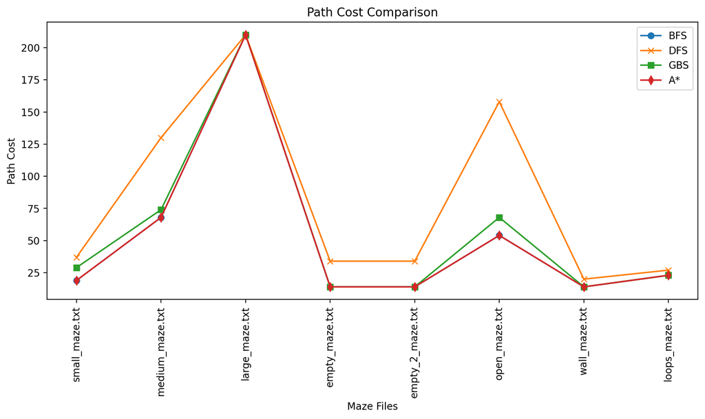

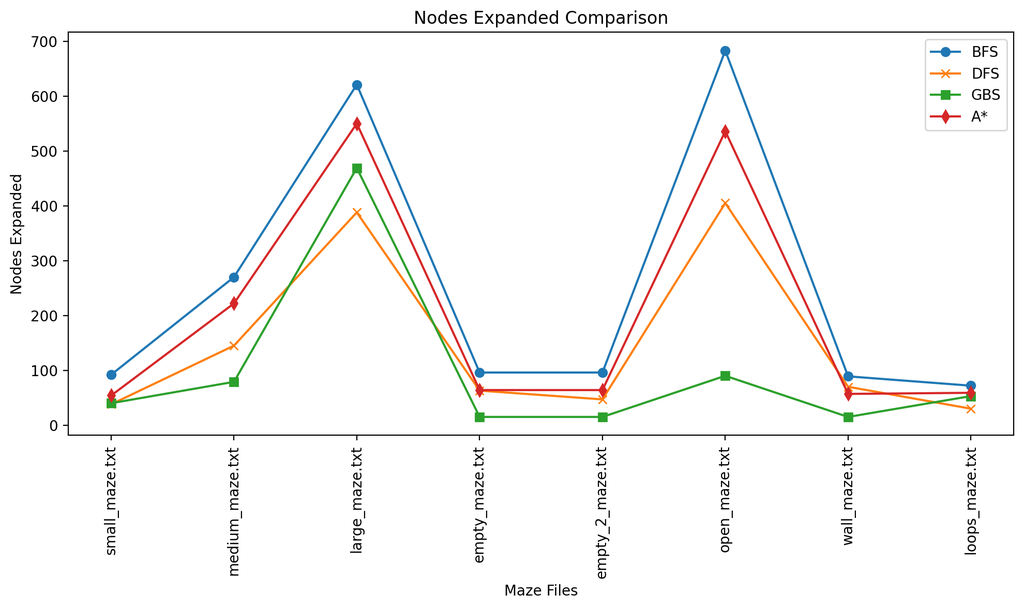

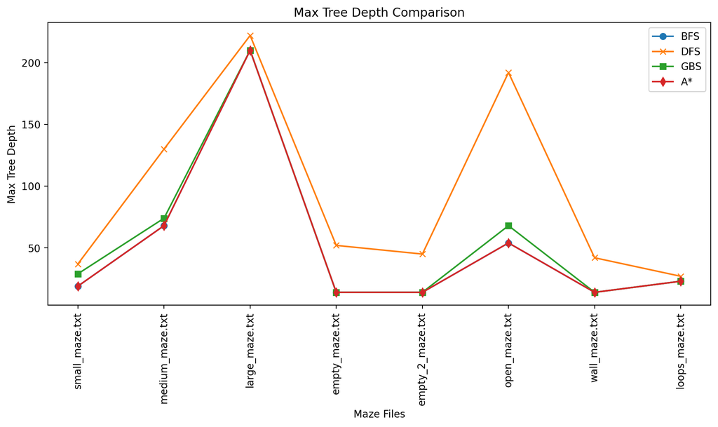

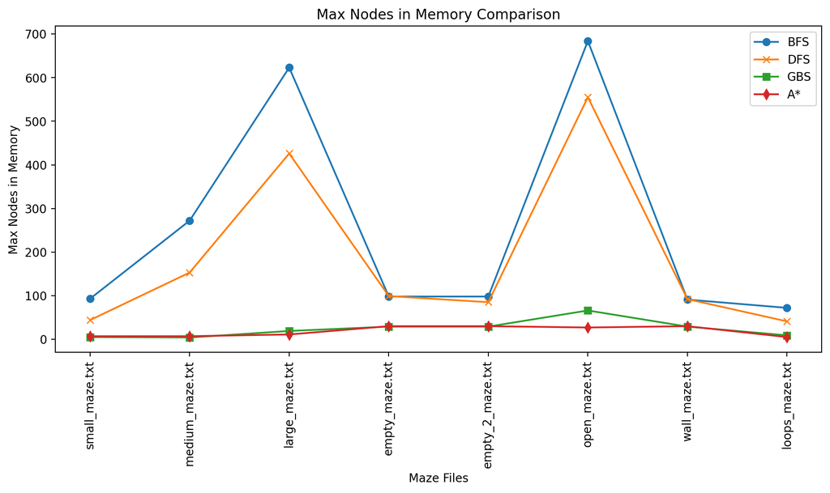

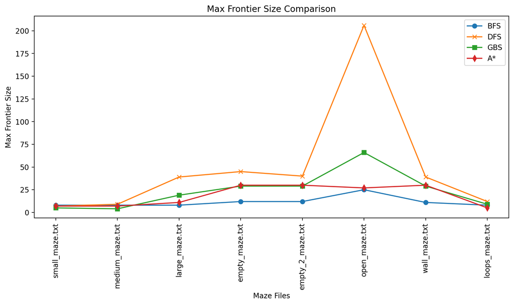

```python
# Add charts
import matplotlib.pyplot as plt

def plot_comparison(metric_name, bfs_data, dfs_data, gbs_data, a_star_data):
    plt.figure(figsize=(10, 6))
    plt.plot(maze_files, bfs_data, label="BFS", marker='o')
    plt.plot(maze_files, dfs_data, label="DFS", marker='x')
    plt.plot(maze_files, gbs_data, label="GBS", marker='s')
    plt.plot(maze_files, a_star_data, label="A*", marker='d')
    plt.xlabel('Maze Files')
    plt.ylabel(metric_name)
    plt.title(f'{metric_name} Comparison')
    plt.xticks(rotation=90)
    plt.legend()
    plt.tight_layout()
    plt.show()

# Plot Path Costs
plot_comparison('Path Cost', bfs_path_costs, dfs_path_costs, gbs_path_costs, a_star_path_costs)

# Plot Nodes Expanded
plot_comparison('Nodes Expanded', bfs_nodes_expanded, dfs_nodes_expanded, gbs_nodes_expanded, a_star_nodes_expanded)

# Plot Max Tree Depth
plot_comparison('Max Tree Depth', bfs_max_tree_depths, dfs_max_tree_depths, gbs_max_tree_depths, a_star_max_tree_depths)

# Plot Max Nodes in Memory
plot_comparison('Max Nodes in Memory', bfs_max_nodes_in_memory, dfs_max_nodes_in_memory, gbs_max_nodes_in_memory, a_star_max_nodes_in_memory)

# Plot Max Frontier Size
plot_comparison('Max Frontier Size', bfs_max_frontier_sizes, dfs_max_frontier_sizes, gbs_max_frontier_sizes, a_star_max_frontier_sizes)
```

Discuss the most important lessons you have learned from implementing the different search strategies.